# Исследование объявлений о продаже квартир

В вашем распоряжении данные сервиса Яндекс Недвижимость — архив объявлений о продаже квартир в Санкт-Петербурге и соседних населённых пунктах за несколько лет. Вам нужно научиться определять рыночную стоимость объектов недвижимости. Для этого проведите исследовательский анализ данных и установите параметры, влияющие на цену объектов. Это позволит построить автоматизированную систему: она отследит аномалии и мошенническую деятельность.

По каждой квартире на продажу доступны два вида данных. Первые вписаны пользователем, вторые — получены автоматически на основе картографических данных. Например, расстояние до центра, аэропорта и других объектов — эти данные автоматически получены из геосервисов. Количество парков и водоёмов также заполняется без участия пользователя.

Исследование объявлений о продаже квартир.

В вашем распоряжении данные сервиса Яндекс Недвижимость — архив объявлений о продаже квартир в Санкт-Петербурге и соседних населённых пунктах за несколько лет. Нужно научиться определять рыночную стоимость объектов недвижимости. Для этого необходимо провести исследовательский анализ данных и установите параметры, влияющие на цену объектов. Это позволит построить автоматизированную систему: она отследит аномалии и мошенническую деятельность. По каждой квартире на продажу доступны два вида данных. Первые вписаны пользователем, вторые — получены автоматически на основе картографических данных. Например, расстояние до центра, аэропорта и других объектов — эти данные автоматически получены из геосервисов. Количество парков и водоёмов также заполняется без участия пользователя.

Цель исследования:

```
1. Определить рыночную стоимость квартир в Санкт-Петербурге и Ленинградской области.

2. Построить автоматизированную систему, которая отследит аномалии и мошенническую деятельность.

3. Установить основные факторы, влияющие на стоимость квартир в Санкт-Петербурге и Ленинградской области.
```

Ход исследования:

```
1. Получить данные из файла '/datasets/real_estate_data.csv'

2. Проверить данные на ошибки и аномалии

3. Устранить ошибки и обработать аномалии

4. Произвести рассчеты и добавить в таблицу необходимые для анализа столбцы

5. Провести анализ для Ленинградской области и визуализировать данные

6. Провести анализ для Санкт-Петербурга и визуализировать данные

7. Сделать общий вывод по исследованию
```

### Откройте файл с данными и изучите общую информацию

#### Выведем первые 10 строк датафрейма.

```python
import pandas as pd
```

```python
import matplotlib.pyplot as plt
```

```python
data = pd.read_csv('/datasets/real_estate_data.csv', sep='\t')
```

```python
data.head(10)
```

|  | total_images | last_price | total_area | first_day_exposition | rooms | ceiling_height | floors_total | living_area | floor | is_apartment | ... | kitchen_area | balcony | locality_name | airports_nearest | cityCenters_nearest | parks_around3000 | parks_nearest | ponds_around3000 | ponds_nearest | days_exposition |
| --- | --- | --- | --- | --- | --- | --- | --- | --- | --- | --- | --- | --- | --- | --- | --- | --- | --- | --- | --- | --- | --- |
| 0 | 20 | 13000000.0 | 108.00 | 2019-03-07T00:00:00 | 3 | 2.70 | 16.0 | 51.00 | 8 | NaN | ... | 25.00 | NaN | Санкт-Петербург | 18863.0 | 16028.0 | 1.0 | 482.0 | 2.0 | 755.0 | NaN |
| 1 | 7 | 3350000.0 | 40.40 | 2018-12-04T00:00:00 | 1 | NaN | 11.0 | 18.60 | 1 | NaN | ... | 11.00 | 2.0 | посёлок Шушары | 12817.0 | 18603.0 | 0.0 | NaN | 0.0 | NaN | 81.0 |
| 2 | 10 | 5196000.0 | 56.00 | 2015-08-20T00:00:00 | 2 | NaN | 5.0 | 34.30 | 4 | NaN | ... | 8.30 | 0.0 | Санкт-Петербург | 21741.0 | 13933.0 | 1.0 | 90.0 | 2.0 | 574.0 | 558.0 |
| 3 | 0 | 64900000.0 | 159.00 | 2015-07-24T00:00:00 | 3 | NaN | 14.0 | NaN | 9 | NaN | ... | NaN | 0.0 | Санкт-Петербург | 28098.0 | 6800.0 | 2.0 | 84.0 | 3.0 | 234.0 | 424.0 |
| 4 | 2 | 10000000.0 | 100.00 | 2018-06-19T00:00:00 | 2 | 3.03 | 14.0 | 32.00 | 13 | NaN | ... | 41.00 | NaN | Санкт-Петербург | 31856.0 | 8098.0 | 2.0 | 112.0 | 1.0 | 48.0 | 121.0 |
| 5 | 10 | 2890000.0 | 30.40 | 2018-09-10T00:00:00 | 1 | NaN | 12.0 | 14.40 | 5 | NaN | ... | 9.10 | NaN | городской посёлок Янино-1 | NaN | NaN | NaN | NaN | NaN | NaN | 55.0 |
| 6 | 6 | 3700000.0 | 37.30 | 2017-11-02T00:00:00 | 1 | NaN | 26.0 | 10.60 | 6 | NaN | ... | 14.40 | 1.0 | посёлок Парголово | 52996.0 | 19143.0 | 0.0 | NaN | 0.0 | NaN | 155.0 |
| 7 | 5 | 7915000.0 | 71.60 | 2019-04-18T00:00:00 | 2 | NaN | 24.0 | NaN | 22 | NaN | ... | 18.90 | 2.0 | Санкт-Петербург | 23982.0 | 11634.0 | 0.0 | NaN | 0.0 | NaN | NaN |
| 8 | 20 | 2900000.0 | 33.16 | 2018-05-23T00:00:00 | 1 | NaN | 27.0 | 15.43 | 26 | NaN | ... | 8.81 | NaN | посёлок Мурино | NaN | NaN | NaN | NaN | NaN | NaN | 189.0 |
| 9 | 18 | 5400000.0 | 61.00 | 2017-02-26T00:00:00 | 3 | 2.50 | 9.0 | 43.60 | 7 | NaN | ... | 6.50 | 2.0 | Санкт-Петербург | 50898.0 | 15008.0 | 0.0 | NaN | 0.0 | NaN | 289.0 |

10 rows × 22 columns

#### Выведем основную информацию о датафрейме.

```python
data.info()
```

```
<class 'pandas.core.frame.DataFrame'>
RangeIndex: 23699 entries, 0 to 23698
Data columns (total 22 columns):
 #   Column                Non-Null Count  Dtype
---  ------                --------------  -----
 0   total_images          23699 non-null  int64
 1   last_price            23699 non-null  float64
 2   total_area            23699 non-null  float64
 3   first_day_exposition  23699 non-null  object
 4   rooms                 23699 non-null  int64
 5   ceiling_height        14504 non-null  float64
 6   floors_total          23613 non-null  float64
 7   living_area           21796 non-null  float64
 8   floor                 23699 non-null  int64
 9   is_apartment          2775 non-null   object
 10  studio                23699 non-null  bool
 11  open_plan             23699 non-null  bool
 12  kitchen_area          21421 non-null  float64
 13  balcony               12180 non-null  float64
 14  locality_name         23650 non-null  object
 15  airports_nearest      18157 non-null  float64
 16  cityCenters_nearest   18180 non-null  float64
 17  parks_around3000      18181 non-null  float64
 18  parks_nearest         8079 non-null   float64
 19  ponds_around3000      18181 non-null  float64
 20  ponds_nearest         9110 non-null   float64
 21  days_exposition       20518 non-null  float64
dtypes: bool(2), float64(14), int64(3), object(3)
memory usage: 3.7+ MB
```

Пропуски присутствуют в 14 столбцах. Отношение пропусков к общему количеству данных доходит до 90% от данных столбца.

#### Построим гистрограммы для всех числовых столбцов датафрейма на одном графике.

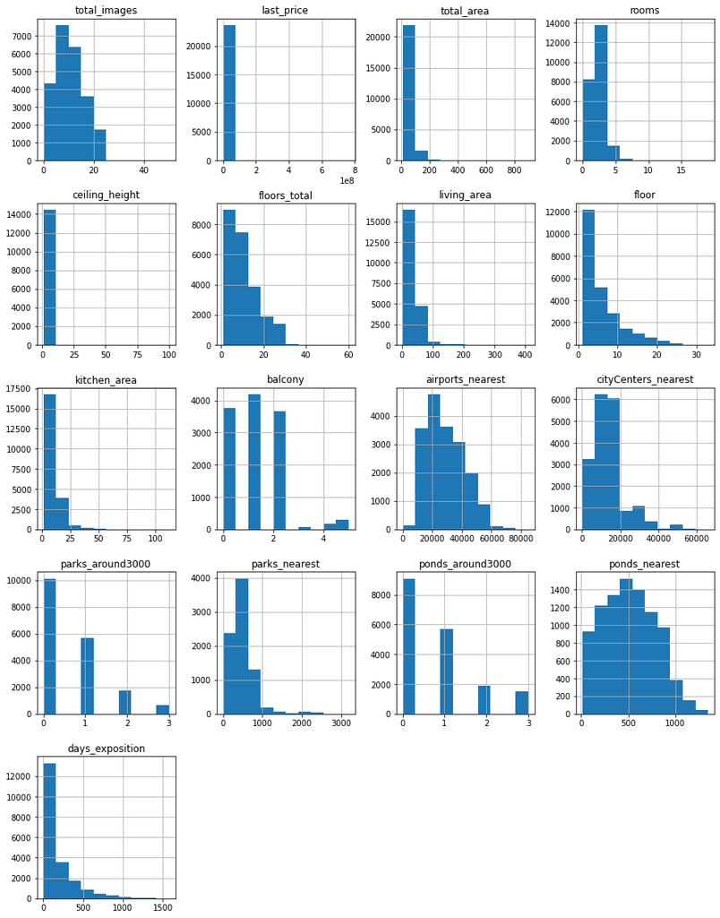

```python
data.select_dtypes(include=['float64', 'int64']).hist(figsize=(15, 20))
plt.show()
```

Гистограммы по столбцам last_price, total_area, living_area, ceiling_height получились совершенно неинформативными, так как максимальные значения столбцов сильно превышают большинство других значений, а также в них присутствуют слишком большие значения. Для наглядности диаграмм можно увеличить количество корзин и исключить слишком большие значения (раздел 4).

Гистограммы по столбцам rooms, floors_total, floor и kitchen_area также выглядят не лучшим образом. Судя по гистограммам, в них присутствуют выбросы, исключив аномально высокие значения, мы сможем построить более информативные гистограммы. (раздел 4)

#### Вывод:

Пропуски присутствуют в 14 столбцах. Отношение пропусков к общему количеству данных доходит до 90% от данных столбца.

По построенным гистограммам видно, что во многих числовых данных (количество фотографий, цена, общая площадь, высота потолков, количество комнат, количество этажей дома, этаж, жилая площадь, площадь кухни) есть выбросы аномально высоких значений. Для того, чтобы более наглядно рассмотреть струтуру распределение данных, в разделе 4 необходимо вывести таблицу с подробным описанием числовых данных и построить новые гистограммы, в каждой из которых будет индивидуально подобрано оптимальное количество корзин и исключены аномально высокие значения.

### Выполните предобработку данных

#### Зададим корректные типы данных.

##### Рассмотрим уникальные значения данных в некоторых столбцах

```python
print (data['is_apartment'].value_counts())
```

```
False    2725
True       50
Name: is_apartment, dtype: int64
```

```python
print (data['balcony'].value_counts())
```

```
1.0    4195
0.0    3758
2.0    3659
5.0     304
4.0     183
3.0      81
Name: balcony, dtype: int64
```

```python
print (data['parks_around3000'].value_counts())
```

```
0.0    10106
1.0     5681
2.0     1747
3.0      647
Name: parks_around3000, dtype: int64
```

```python
print (data['ponds_around3000'].value_counts())
```

```
0.0    9071
1.0    5717
2.0    1892
3.0    1501
Name: ponds_around3000, dtype: int64
```

##### Изменим типы данных в стобцах.

```python
data['last_price'] = data['last_price'].astype('int')
```

```python
data['is_apartment'] = data['is_apartment'].astype('bool')
```

```python
data['balcony'] = data['balcony'].astype('int8', errors='ignore')
```

```python
data['parks_around3000'] = data['parks_around3000'].astype('int8', errors='ignore')
```

```python
data['ponds_around3000'] = data['ponds_around3000'].astype('int8', errors='ignore')
```

```python
data['first_day_exposition'] = pd.to_datetime(data['first_day_exposition'], format='%Y-%m-%d %H:%M:%S')
```

```python
data.info()
```

```
<class 'pandas.core.frame.DataFrame'>
RangeIndex: 23699 entries, 0 to 23698
Data columns (total 22 columns):
 #   Column                Non-Null Count  Dtype
---  ------                --------------  -----
 0   total_images          23699 non-null  int64
 1   last_price            23699 non-null  int64
 2   total_area            23699 non-null  float64
 3   first_day_exposition  23699 non-null  datetime64[ns]
 4   rooms                 23699 non-null  int64
 5   ceiling_height        14504 non-null  float64
 6   floors_total          23613 non-null  float64
 7   living_area           21796 non-null  float64
 8   floor                 23699 non-null  int64
 9   is_apartment          23699 non-null  bool
 10  studio                23699 non-null  bool
 11  open_plan             23699 non-null  bool
 12  kitchen_area          21421 non-null  float64
 13  balcony               12180 non-null  float64
 14  locality_name         23650 non-null  object
 15  airports_nearest      18157 non-null  float64
 16  cityCenters_nearest   18180 non-null  float64
 17  parks_around3000      18181 non-null  float64
 18  parks_nearest         8079 non-null   float64
 19  ponds_around3000      18181 non-null  float64
 20  ponds_nearest         9110 non-null   float64
 21  days_exposition       20518 non-null  float64
dtypes: bool(3), datetime64[ns](1), float64(13), int64(4), object(1)
memory usage: 3.5+ MB
```

Тип данных стобца is_apartment изменен с object на bool. Во-первых это необходимо для проверки предположения о том, что пропуски в площади кухни и жилой площади связаны с типом квартиры. Во-вторых начения типа bool занимают намного меньше памяти, чем значения типа object. Для значений столбцов с ценой, количеством балконов, количеством парков и водоемов в радиусе 3 км, можно использовать целочисленные значения, причем для последних трех можно использовать тип int8, так как там нужны числа только от 0 до 5, это сократит объем занимаемой памяти примерно на 14%.

#### Обработаем пропущенные значения.

##### Количество пропусков в каждом столбце.

```python
data.isna().sum()
```

```
total_images                0
last_price                  0
total_area                  0
first_day_exposition        0
rooms                       0
ceiling_height           9195
floors_total               86
living_area              1903
floor                       0
is_apartment                0
studio                      0
open_plan                   0
kitchen_area             2278
balcony                 11519
locality_name              49
airports_nearest         5542
cityCenters_nearest      5519
parks_around3000         5518
parks_nearest           15620
ponds_around3000         5518
ponds_nearest           14589
days_exposition          3181
dtype: int64
```

##### Общее количество пропусков в таблице.

```python
data.isna().sum().sum()
```

```
80517
```

##### Процентное соотношение пропусков к общему числу значений для каждого столбца.

```python
pd.DataFrame(round(data.isna().mean()*100,)).style.background_gradient('coolwarm')
```

|  | 0 |
| --- | --- |
| total_images | 0.000000 |
| last_price | 0.000000 |
| total_area | 0.000000 |
| first_day_exposition | 0.000000 |
| rooms | 0.000000 |
| ceiling_height | 39.000000 |
| floors_total | 0.000000 |
| living_area | 8.000000 |
| floor | 0.000000 |
| is_apartment | 0.000000 |
| studio | 0.000000 |
| open_plan | 0.000000 |
| kitchen_area | 10.000000 |
| balcony | 49.000000 |
| locality_name | 0.000000 |
| airports_nearest | 23.000000 |
| cityCenters_nearest | 23.000000 |
| parks_around3000 | 23.000000 |
| parks_nearest | 66.000000 |
| ponds_around3000 | 23.000000 |
| ponds_nearest | 62.000000 |
| days_exposition | 13.000000 |

##### Причины возникновения пропусков.

Пропуски в высоте потолков и общему количеству этажей можно заполнить медианными значениями этих столбцов, а пропуски в столбцах с жилой площадью и площадью кухни заполнить с помощью данных об общей площади квартиры.

Возможен вариант, что данные о жилой площади и площади кухни не указаны для квартир типа "студия", "аппартамены" или "свободная планировка", так как в таких квартирах может не быть четкого разделения на жилуюплощадь и кухню. Это предположение проверим ниже.

Если в объявлении не указано количество балконов - вероятно их нет, поэтому пропущенные значения можно заменить на 0.

Если не указано количество парков и водоемов в радиусе 3 км - вероятно их нет, поэтому пропущенные значения заменим на 0.

Возможно пропуски в данных о расстоянии до ближайшего водоема и парка обусловлены тем, что в радиусе 3 км их нет. Проверим это предположение ниже.

Пропускам в столбце названия населенного пункта присвоим значение "Другое".

##### Возможно пропуски в площади кухни обусловлены типом квартиры (студия, аппартаменты, свободная планировка). Проверим предположение.

```python
print (len(data.query('kitchen_area.isna() and studio==True')))
print (len(data.query('kitchen_area.isna() and open_plan==True')))
len(data.query('kitchen_area.isna() and is_apartment==True'))
```

```
149
67
```

```
2103
```

Предположение не подтвердилось.

##### Возможно пропуски в жилой площади обусловлены типом квартиры (студия, аппартаменты, свободная планировка). Проверим предположение.

```python
print (len(data.query('living_area.isna() and studio==True')))
print (len(data.query('living_area.isna() and open_plan==True')))
len(data.query('living_area.isna() and is_apartment==True'))
```

```
10
5
```

```
1791
```

Предположение не подтвердилось.

##### Возможно пропуски в количестве этажей обусловлены тем, что дом, в котором находится квартира одноэтажный, тогда все квартры, для которых не указана этажность дома будут располагаться на первом этаже. Проверим предположение.

```python
len(data.query('floors_total.isna() and floor==1'))
```

```
3
```

Всего пропусков в количестве этажей 86, из этих объявлений 3 квартиры находятся на первом этаже.

Предположение не подтвердилось.

##### Возможно пропуски в данных о расстоянии до ближайшего водоема обусловлены тем, что в радиусе 3 км их нет. Проверим предположение.

```python
len(data.query('ponds_nearest.isna() and ponds_around3000==0'))
```

```
9071
```

##### Возможно пропуски в данных о расстоянии до ближайшего парка обусловлены тем, что в радиусе 3 км их нет. Проверим предположение.

```python
len(data.query('parks_nearest.isna() and parks_around3000==0'))
```

```
10102
```

##### Заполним пропуски по количеству балконов.

```python
data['balcony'] = data['balcony'].fillna(0)
```

##### Заполним пропуски по столбцу "аппартаменты".

```python
data['is_apartment'] = data['is_apartment'].fillna(False)
```

##### Заполним пропуски по названию населенного пункта.

```python
data['locality_name'] = data['locality_name'].fillna('Другое')
```

```python
data['parks_around3000'] = data['parks_around3000'].fillna(0)
```

##### Заполним пропуски по количеству водоемов в радиусе 3 км.

```python
data['ponds_around3000'] = data['ponds_around3000'].fillna(0)
```

```python
data['parks_around3000'] = data['parks_around3000'].fillna(0)
```

##### Посмотрим сколько в среднем составляет площадь кухни и жилая площадь от общей площади квартиры. Будем использовать медианные значения, чтобы анамолии не искажали средний результат.

```python
(data['kitchen_area']/data['total_area']).median()
```

```
0.1724137931034483
```

В среднем площадь кухни составляет 17% от общей площади.

```python
(data['living_area']/data['total_area']).median()
```

```
0.5678598992678503
```

В среднем жилая составляет 57% от общей площади.

##### Заполним пропуски в площади кухни, они будут составлять 17% от общей площади квартиры.

```python
data['kitchen_area'] = data['kitchen_area'].fillna(data['total_area']*0.17)
```

##### Заполним пропуски в жилой площади, они будут составлять 57% от общей площади квартиры.

```python
data['living_area'] = data['living_area'].fillna(data['total_area']*0.57)
```

##### Заполним пропуски в высоте потолков медианным значением.

```python
data['ceiling_height'] = data['ceiling_height'].fillna(data['ceiling_height'].median())
```

##### Заполним пропуски по общему количеству этажей.

```python
data['floors_total'] = data['floors_total'].fillna(data['floors_total'].median())
```

```python
data.isna().sum()
```

```
total_images                0
last_price                  0
total_area                  0
first_day_exposition        0
rooms                       0
ceiling_height              0
floors_total                0
living_area                 0
floor                       0
is_apartment                0
studio                      0
open_plan                   0
kitchen_area                0
balcony                     0
locality_name               0
airports_nearest         5542
cityCenters_nearest      5519
parks_around3000            0
parks_nearest           15620
ponds_around3000            0
ponds_nearest           14589
days_exposition          3181
dtype: int64
```

```python
data.isna().sum().sum()
```

```
44451
```

#### Изучим уникальные значения в столбце с названиями.

```python
data['locality_name'].unique()
```

```
array(['Санкт-Петербург', 'посёлок Шушары', 'городской посёлок Янино-1',
       'посёлок Парголово', 'посёлок Мурино', 'Ломоносов', 'Сертолово',
       'Петергоф', 'Пушкин', 'деревня Кудрово', 'Коммунар', 'Колпино',
       'поселок городского типа Красный Бор', 'Гатчина', 'поселок Мурино',
       'деревня Фёдоровское', 'Выборг', 'Кронштадт', 'Кировск',
       'деревня Новое Девяткино', 'посёлок Металлострой',
       'посёлок городского типа Лебяжье',
       'посёлок городского типа Сиверский', 'поселок Молодцово',
       'поселок городского типа Кузьмоловский',
       'садовое товарищество Новая Ропша', 'Павловск',
       'деревня Пикколово', 'Всеволожск', 'Волхов', 'Кингисепп',
       'Приозерск', 'Сестрорецк', 'деревня Куттузи', 'посёлок Аннино',
       'поселок городского типа Ефимовский', 'посёлок Плодовое',
       'деревня Заклинье', 'поселок Торковичи', 'поселок Первомайское',
       'Красное Село', 'посёлок Понтонный', 'Сясьстрой', 'деревня Старая',
       'деревня Лесколово', 'посёлок Новый Свет', 'Сланцы',
       'село Путилово', 'Ивангород', 'Мурино', 'Шлиссельбург',
       'Никольское', 'Зеленогорск', 'Сосновый Бор', 'поселок Новый Свет',
       'деревня Оржицы', 'деревня Кальтино', 'Кудрово',
       'поселок Романовка', 'посёлок Бугры', 'поселок Бугры',
       'поселок городского типа Рощино', 'Кириши', 'Луга', 'Волосово',
       'Отрадное', 'село Павлово', 'поселок Оредеж', 'село Копорье',
       'посёлок городского типа Красный Бор', 'посёлок Молодёжное',
       'Тихвин', 'посёлок Победа', 'деревня Нурма',
       'поселок городского типа Синявино', 'Тосно',
       'посёлок городского типа Кузьмоловский', 'посёлок Стрельна',
       'Бокситогорск', 'посёлок Александровская', 'деревня Лопухинка',
       'Пикалёво', 'поселок Терволово',
       'поселок городского типа Советский', 'Подпорожье',
       'посёлок Петровское', 'посёлок городского типа Токсово',
       'поселок Сельцо', 'посёлок городского типа Вырица',
       'деревня Кипень', 'деревня Келози', 'деревня Вартемяги',
       'посёлок Тельмана', 'поселок Севастьяново',
       'городской поселок Большая Ижора', 'Другое',
       'городской посёлок Павлово', 'деревня Агалатово',
       'посёлок Новогорелово', 'городской посёлок Лесогорский',
       'деревня Лаголово', 'поселок Цвелодубово',
       'поселок городского типа Рахья', 'поселок городского типа Вырица',
       'деревня Белогорка', 'поселок Заводской',
       'городской посёлок Новоселье', 'деревня Большие Колпаны',
```

[output cut: 92 more lines]

```
       'деревня Ям-Тесово', 'деревня Раздолье', 'деревня Терпилицы',
       'посёлок Шугозеро', 'деревня Ваганово', 'поселок Пушное',
       'садовое товарищество Садко', 'посёлок Усть-Ижора',
       'деревня Выскатка', 'городской посёлок Свирьстрой',
       'поселок Громово', 'деревня Кисельня', 'посёлок Старая Малукса',
       'деревня Трубников Бор', 'поселок Калитино',
       'посёлок Высокоключевой', 'садовое товарищество Приладожский',
       'посёлок Пансионат Зелёный Бор', 'деревня Ненимяки',
       'поселок Пансионат Зелёный Бор', 'деревня Снегирёвка',
       'деревня Рапполово', 'деревня Пустынка', 'поселок Рабитицы',
       'деревня Большой Сабск', 'деревня Русско', 'деревня Лупполово',
       'деревня Большое Рейзино', 'деревня Малая Романовка',
       'поселок Дружноселье', 'поселок Пчевжа', 'поселок Володарское',
       'деревня Нижняя', 'коттеджный посёлок Лесное', 'деревня Тихковицы',
       'деревня Борисова Грива', 'посёлок Дзержинского'], dtype=object)
```

```python
data['locality_name'].value_counts()
```

```
Санкт-Петербург                   15721
посёлок Мурино                      522
посёлок Шушары                      440
Всеволожск                          398
Пушкин                              369
                                  ...
поселок Калитино                      1
посёлок Форт Красная Горка            1
поселок Гончарово                     1
посёлок городского типа Рябово        1
деревня Вахнова Кара                  1
Name: locality_name, Length: 365, dtype: int64
```

Столбец с названиями населенных пунктов содержит 365 значений. В списке уникальных значений заметны неявные дубликаты.

##### Избавимся от неявных дубликатов.

```python
data['locality_name'] = (
    data['locality_name']
    .str.replace('ё', 'е').replace('садоводческое некоммерческое товарищество','садоводческое товарищество')
    .replace(['посёлок городского типа', 'городской поселок', 'поселок станции', 'коттеджный поселок'], 'поселок', regex=True)
)
```

Поменяла местами разделы 2.1 и 2.2, так получается логичнее.

##### Посмотрим, сколько осталось уникальных значений в столбце.

```python
data['locality_name'].value_counts()
```

```
Санкт-Петербург                                            15721
поселок Мурино                                               556
поселок Шушары                                               440
Всеволожск                                                   398
Пушкин                                                       369
                                                           ...
садоводческое некоммерческое товарищество Лесная Поляна        1
деревня Зимитицы                                               1
деревня Пикколово                                              1
деревня Большой Сабск                                          1
село Шум                                                       1
Name: locality_name, Length: 329, dtype: int64
```

Получилось найти и избавится от 36 неявных дубликатов.

##### Проверим таблицу на явные дубликаты.

```python
data.duplicated().sum()
```

```
0
```

Явных дубликатов в таблице не обнаружено.

#### Вывод:

Тип данных стобца is_apartment изменен с object на bool. Во-первых это было необходимо для проверки предположения о том, что пропуски в площади кухни и жилой площади связаны с типом квартиры. Во-вторых начения типа bool занимают намного меньше памяти, чем значения типа object.

Для значений столбцов с ценой, количеством балконов, количеством парков и водоемов в радиусе 3 км, можно использовать целочисленные значения, причем для последних трех можно использовать тип int8, так как там нужны числа только от 0 до 5, это сократит объем занимаемой памяти примерно на 14%.

Пропуски в высоте потолков и общему количеству этажей можно заполнить медианными значениями этих столбцов, а пропуски в столбцах с жилой площадью и площадью кухни заполнить с помощью данных об общей площади квартиры.

Если в объявлении не указано количество балконов - вероятно их нет, поэтому пропущенные значения заменены на 0.

Если не указано количество парков и водоемов в радиусе 3 км - вероятно их нет, поэтому пропущенные значения заменены на 0.

Пропускам в столбце названия населенного пункта присвоено значение "Другое".

Пропуски в данных о жилой площади, площади кухни и высоте потолков можно объяснить человеческим фактором (автор объявления решил не указывать эти данные), техническим сбоем.

Было найдено и удалено 36 неявных дубликатов в столбце с названиями населенных пунктов, из 365 осталось 329.

Явных дубликатов в данных не обнаружено.

### Добавьте в таблицу новые столбцы

#### Добавим в таблицу новый столбец с ценой одного квадратного метра.

```python
data['meter_price'] = data['last_price']/data['total_area']
```

#### Добавим в таблицу новый столбец с днем недели публикации объявления .

```python
data['weekday_exposition'] = data['first_day_exposition'].dt.weekday
```

#### Добавим в таблицу новый столбец с месяцем публикации объявления .

```python
data['month_exposition'] = data['first_day_exposition'].dt.month
```

#### Добавим в таблицу новый столбец с годом публикации объявления .

```python
data['year_exposition'] = data['first_day_exposition'].dt.year
```

#### Добавим в таблицу новый столбец с типом этажа квартиры .

```python
def floor_type(row):
    if row['floor'] == 1:
        return 'первый'
    if row['floor'] == row['floors_total']:
        return 'последний'
    else:
        return 'другой'

data['floor_type'] = data.apply(floor_type, axis=1)
```

#### Добавим в таблицу новый столбец с расстоянием до центра города в километрах .

```python
data['city_centers_nearest_km'] = (data['cityCenters_nearest']/1000).round()
```

#### Выведем первые 10 сторк обновленной таблицы

```python
data.head(10)
```

|  | total_images | last_price | total_area | first_day_exposition | rooms | ceiling_height | floors_total | living_area | floor | is_apartment | ... | parks_nearest | ponds_around3000 | ponds_nearest | days_exposition | meter_price | weekday_exposition | month_exposition | year_exposition | floor_type | city_centers_nearest_km |
| --- | --- | --- | --- | --- | --- | --- | --- | --- | --- | --- | --- | --- | --- | --- | --- | --- | --- | --- | --- | --- | --- |
| 0 | 20 | 13000000 | 108.00 | 2019-03-07 | 3 | 2.70 | 16.0 | 51.000 | 8 | True | ... | 482.0 | 2.0 | 755.0 | NaN | 120370.370370 | 3 | 3 | 2019 | другой | 16.0 |
| 1 | 7 | 3350000 | 40.40 | 2018-12-04 | 1 | 2.65 | 11.0 | 18.600 | 1 | True | ... | NaN | 0.0 | NaN | 81.0 | 82920.792079 | 1 | 12 | 2018 | первый | 19.0 |
| 2 | 10 | 5196000 | 56.00 | 2015-08-20 | 2 | 2.65 | 5.0 | 34.300 | 4 | True | ... | 90.0 | 2.0 | 574.0 | 558.0 | 92785.714286 | 3 | 8 | 2015 | другой | 14.0 |
| 3 | 0 | 64900000 | 159.00 | 2015-07-24 | 3 | 2.65 | 14.0 | 90.630 | 9 | True | ... | 84.0 | 3.0 | 234.0 | 424.0 | 408176.100629 | 4 | 7 | 2015 | другой | 7.0 |
| 4 | 2 | 10000000 | 100.00 | 2018-06-19 | 2 | 3.03 | 14.0 | 32.000 | 13 | True | ... | 112.0 | 1.0 | 48.0 | 121.0 | 100000.000000 | 1 | 6 | 2018 | другой | 8.0 |
| 5 | 10 | 2890000 | 30.40 | 2018-09-10 | 1 | 2.65 | 12.0 | 14.400 | 5 | True | ... | NaN | 0.0 | NaN | 55.0 | 95065.789474 | 0 | 9 | 2018 | другой | NaN |
| 6 | 6 | 3700000 | 37.30 | 2017-11-02 | 1 | 2.65 | 26.0 | 10.600 | 6 | True | ... | NaN | 0.0 | NaN | 155.0 | 99195.710456 | 3 | 11 | 2017 | другой | 19.0 |
| 7 | 5 | 7915000 | 71.60 | 2019-04-18 | 2 | 2.65 | 24.0 | 40.812 | 22 | True | ... | NaN | 0.0 | NaN | NaN | 110544.692737 | 3 | 4 | 2019 | другой | 12.0 |
| 8 | 20 | 2900000 | 33.16 | 2018-05-23 | 1 | 2.65 | 27.0 | 15.430 | 26 | True | ... | NaN | 0.0 | NaN | 189.0 | 87454.764777 | 2 | 5 | 2018 | другой | NaN |
| 9 | 18 | 5400000 | 61.00 | 2017-02-26 | 3 | 2.50 | 9.0 | 43.600 | 7 | True | ... | NaN | 0.0 | NaN | 289.0 | 88524.590164 | 6 | 2 | 2017 | другой | 15.0 |

10 rows × 28 columns

#### Вывод

Для дальнейшего проведения анализа были добавлены столбцы: цена одного квадратного метра; день недели публикации объявления (0 — понедельник, 1 — вторник и так далее); месяц публикации объявления; год публикации объявления; тип этажа квартиры (значения — «первый», «последний», «другой»); расстояние до центра города в километрах.

### Проведите исследовательский анализ данных

#### Выведем числовое описание датафрема.

```python
data.describe()
```

|  | total_images | last_price | total_area | rooms | ceiling_height | floors_total | living_area | floor | kitchen_area | balcony | ... | parks_around3000 | parks_nearest | ponds_around3000 | ponds_nearest | days_exposition | meter_price | weekday_exposition | month_exposition | year_exposition | city_centers_nearest_km |
| --- | --- | --- | --- | --- | --- | --- | --- | --- | --- | --- | --- | --- | --- | --- | --- | --- | --- | --- | --- | --- | --- |
| count | 23699.000000 | 2.369900e+04 | 23699.000000 | 23699.000000 | 23699.000000 | 23699.000000 | 23699.000000 | 23699.000000 | 23699.000000 | 23699.000000 | ... | 23699.000000 | 8079.000000 | 23699.000000 | 9110.000000 | 20518.000000 | 2.369900e+04 | 23699.000000 | 23699.000000 | 23699.000000 | 18180.000000 |
| mean | 9.858475 | 6.541549e+06 | 60.348651 | 2.070636 | 2.724358 | 10.667750 | 34.589095 | 5.892358 | 10.478304 | 0.591080 | ... | 0.469049 | 490.804555 | 0.590911 | 517.980900 | 180.888634 | 9.942166e+04 | 2.569307 | 6.400101 | 2017.367146 | 14.184818 |
| std | 5.682529 | 1.088701e+07 | 35.654083 | 1.078405 | 0.988298 | 6.585961 | 22.350250 | 4.885249 | 6.019754 | 0.959298 | ... | 0.748534 | 342.317995 | 0.883999 | 277.720643 | 219.727988 | 5.030680e+04 | 1.789082 | 3.491561 | 1.039771 | 8.616194 |
| min | 0.000000 | 1.219000e+04 | 12.000000 | 0.000000 | 1.000000 | 1.000000 | 2.000000 | 1.000000 | 1.300000 | 0.000000 | ... | 0.000000 | 1.000000 | 0.000000 | 13.000000 | 1.000000 | 1.118349e+02 | 0.000000 | 1.000000 | 2014.000000 | 0.000000 |
| 25% | 6.000000 | 3.400000e+06 | 40.000000 | 1.000000 | 2.600000 | 5.000000 | 19.000000 | 2.000000 | 7.000000 | 0.000000 | ... | 0.000000 | 288.000000 | 0.000000 | 294.000000 | 45.000000 | 7.658547e+04 | 1.000000 | 3.000000 | 2017.000000 | 9.000000 |
| 50% | 9.000000 | 4.650000e+06 | 52.000000 | 2.000000 | 2.650000 | 9.000000 | 30.000000 | 4.000000 | 9.000000 | 0.000000 | ... | 0.000000 | 455.000000 | 0.000000 | 502.000000 | 95.000000 | 9.500000e+04 | 3.000000 | 6.000000 | 2017.000000 | 13.000000 |
| 75% | 14.000000 | 6.800000e+06 | 69.900000 | 3.000000 | 2.700000 | 16.000000 | 42.100000 | 8.000000 | 12.000000 | 1.000000 | ... | 1.000000 | 612.000000 | 1.000000 | 729.000000 | 232.000000 | 1.142563e+05 | 4.000000 | 10.000000 | 2018.000000 | 16.000000 |
| max | 50.000000 | 7.630000e+08 | 900.000000 | 19.000000 | 100.000000 | 60.000000 | 409.700000 | 33.000000 | 112.000000 | 5.000000 | ... | 3.000000 | 3190.000000 | 3.000000 | 1344.000000 | 1580.000000 | 1.907500e+06 | 6.000000 | 12.000000 | 2019.000000 | 66.000000 |

8 rows × 22 columns

##### В некоторых параметрах встречаются редкие и выбивающиеся значения, их можно либо исправить, либо удалить строки с ними.

Обработаем аномалии в столбце с высотой потолка.

```python
def ceiling_height(ceiling_height):
    if ceiling_height > 10:
        return ceiling_height/10
    else:
        return ceiling_height

data['ceiling_height'] = data['ceiling_height'].apply(ceiling_height)
```

На основании данных числового описания таблицы построим наглядные гистограммы.

##### Гистограмма общей площади.

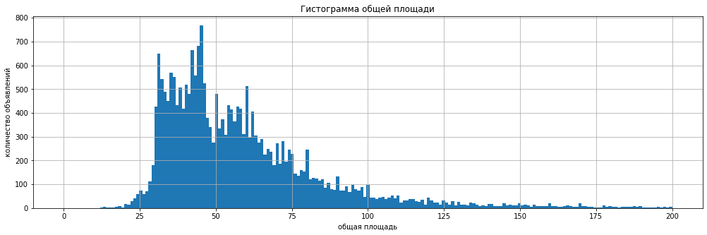

```python
plt.figure(figsize=(17,5))
data['total_area'].hist(bins=201, range=(0, 200))
plt.title('Гистограмма общей площади')
plt.ylabel('количество объявлений')
plt.xlabel('общая площадь')
plt.show()
```

Для общей площади пик расположен на значении 45 м, максимальное значение 900, минимальное 12, медианное значение 52, среднее 60. Аномально высокие значения увеличивают среднее арифметическое. Значения от 200 и выше можно отбросить.

##### Гистограмма жилой площади.

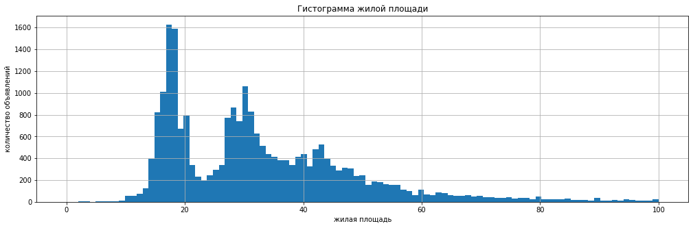

```python
plt.figure(figsize=(17,5))
data['living_area'].hist(bins=101, range=(0, 100))
plt.title('Гистограмма жилой площади')
plt.ylabel('количество объявлений')
plt.xlabel('жилая площадь')
plt.show()
```

Для жилой площади пики расположены на значениях 18 и 30 м, максимальное значение 410, минимальное 2, медианное значение 30, среднее 34. Аномально высокие значения увеличивают среднее арифметическое. Значения от 100 и выше можно отбросить.

##### Гистограмма площади кухни.

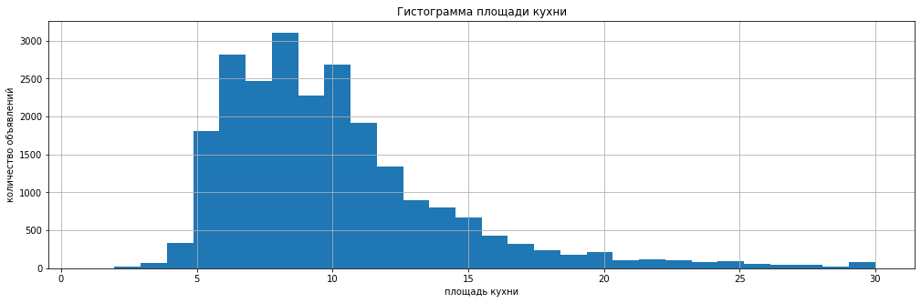

```python
plt.figure(figsize=(17,5))
data['kitchen_area'].hist(bins=30, range=(1, 30))
plt.title('Гистограмма площади кухни')
plt.ylabel('количество объявлений')
plt.xlabel('площадь кухни')
plt.show()
```

##### Гистограмма цены объекта.

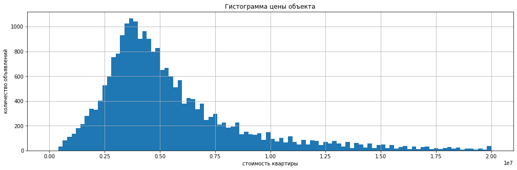

```python
plt.figure(figsize=(17,5))
data['last_price'].hist(bins=100, range=(0, 20000000))
plt.title('Гистограмма цены объекта')
plt.ylabel('количество объявлений')
plt.xlabel('стоимость квартиры')
plt.show()
```

Для цены пик расположен на значении 4 000 000, максимальное значение 763 000 000, минимальное 12 190, медианное значение цены 4 600 000, среднее 6 600 000. Аномально высокие значения увеличивают среднее арифметическое. Значения от 20 млн и выше можно отбросить.

##### Гистограмма количества комнат.

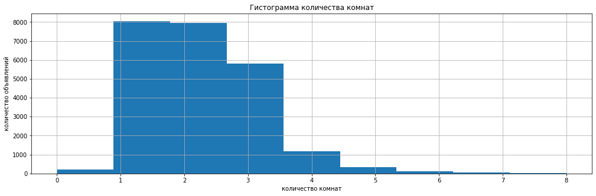

```python
plt.figure(figsize=(17,5))
data['rooms'].hist(bins=9, range=(0, 8))
plt.title('Гистограмма количества комнат')
plt.ylabel('количество объявлений')
plt.xlabel('количество комнат')
plt.show()
```

Для количства комнат пик расположен на значении 1-2 комнаты , максимальное значение 19, минимальное 0, медианное значение 2, среднее 2. Аномально высокие значения не увеличивают среднее арифметическое, так как их крайне мало. Значения от 8 и выше можно отбросить.

##### Гистограмма высоты потолков.

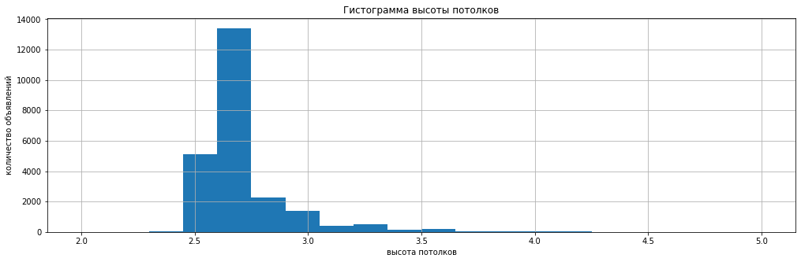

```python
plt.figure(figsize=(17,5))
data['ceiling_height'].hist(bins=20, range=(2, 5))
plt.title('Гистограмма высоты потолков')
plt.ylabel('количество объявлений')
plt.xlabel('высота потолков')
plt.show()
```

##### Гистограмма типа этажа.

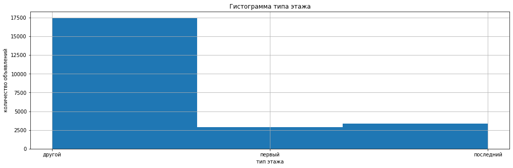

```python
plt.figure(figsize=(17,5))
data['floor_type'].hist(bins=3)
plt.title('Гистограмма типа этажа')
plt.ylabel('количество объявлений')
plt.xlabel('тип этажа')
plt.show()
```

Большинство предложений расположено на этажах типа "другой" (не первый и не последний), распределение первого и последнего этажа равномерное, примерно по 15% от общего числа.

##### Гистограмма общего количества этажей в доме.

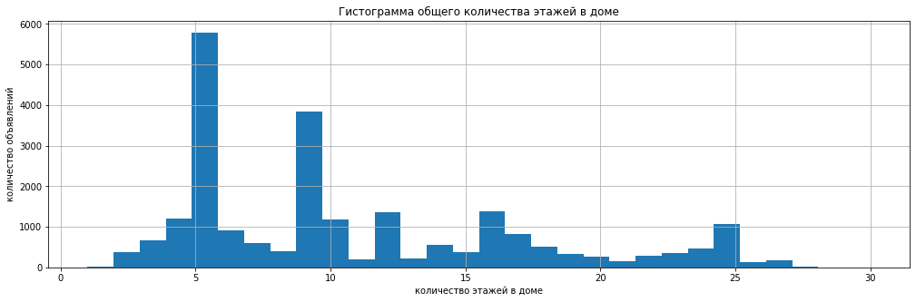

```python
plt.figure(figsize=(17,5))
data['floors_total'].hist(bins=30, range=(1, 30))
plt.title('Гистограмма общего количества этажей в доме')
plt.ylabel('количество объявлений')
plt.xlabel('количество этажей в доме')
plt.show()
```

Для количества этажей пики расположены на значениях 5, 9, 12, 17 и 24, максимальное значение 60, минимальное 1, медианное значение 9, среднее 11. Аномально высокие значения незначительно увеличивают среднее арифметическое, потому что их крайне мало. Значения от 30 и выше можно отбросить.

##### Гистограмма растояния до центра города в метрах.

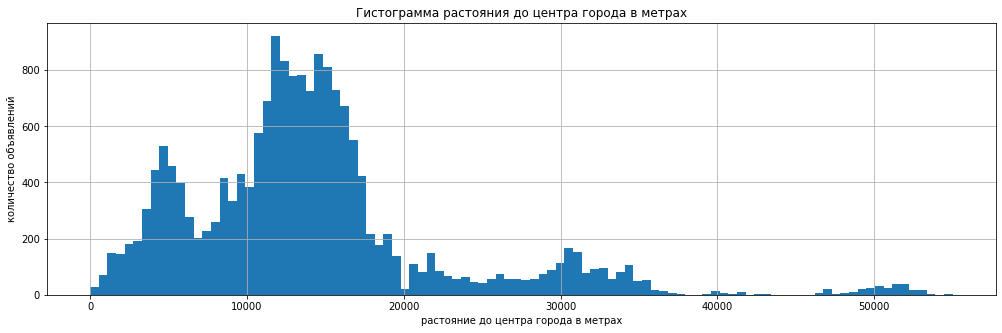

```python
plt.figure(figsize=(17,5))
data['cityCenters_nearest'].hist(bins=100, range=(0, 55000))
plt.title('Гистограмма растояния до центра города в метрах')
plt.ylabel('количество объявлений')
plt.xlabel('растояние до центра города в метрах')
plt.show()
```

Растояние до центра города чаще всего в районе 10-15 км, разброс от 0 до 66 км.

##### Гистограмма растояния до ближайшего парка в метрах.

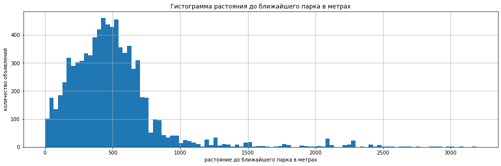

```python
plt.figure(figsize=(17,5))
data['parks_nearest'].hist(bins=100, range=(1, 3190))
plt.title('Гистограмма растояния до ближайшего парка в метрах')
plt.ylabel('количество объявлений')
plt.xlabel('растояние до ближайшего парка в метрах')
plt.show()
```

Для тех квартир, где в радиусе 3 км есть парки, в среднем до ближайщего парка около 500 м.

##### Создадим срез данных.

```python
data_stat = data.query('total_area <= 200 and living_area <= 100 and kitchen_area <= 30 and last_price <= 20000000 and rooms <= 8 and ceiling_height <= 5 and floors_total <=30')
data_stat.info()
```

```
<class 'pandas.core.frame.DataFrame'>
Int64Index: 22646 entries, 0 to 23698
Data columns (total 28 columns):
 #   Column                   Non-Null Count  Dtype
---  ------                   --------------  -----
 0   total_images             22646 non-null  int64
 1   last_price               22646 non-null  int64
 2   total_area               22646 non-null  float64
 3   first_day_exposition     22646 non-null  datetime64[ns]
 4   rooms                    22646 non-null  int64
 5   ceiling_height           22646 non-null  float64
 6   floors_total             22646 non-null  float64
 7   living_area              22646 non-null  float64
 8   floor                    22646 non-null  int64
 9   is_apartment             22646 non-null  bool
```

[output cut: 20 more lines]

В некоторых параметрах встречаются редкие и выбивающиеся значения, их можно либо исправить, либо удалить строки с ними.

В столбце с высотой потолка аномальные значения выше 10м скорее всего неправильно записаны. Можно устранить часть аномалий разделив такие значения на 10.

Для общей площади пик расположен на значении 45 м, максимальное значение 900, минимальное 12, медианное значение 52, среднее 60. Аномально высокие значения увеличивают среднее арифметическое. Значения от 200 и выше можно отбросить.

Для жилой площади пики расположены на значениях 18 и 30 м, максимальное значение 410, минимальное 2, медианное значение 30, среднее 34. Аномально высокие значения увеличивают среднее арифметическое. Значения от 100 и выше можно отбросить.

Для цены пик расположен на значении 4 000 000, максимальное значение 763 000 000, минимальное 12 190, медианное значение цены 4 600 000, среднее 6 600 000. Аномально высокие значения увеличивают среднее арифметическое. Значения от 20 млн и выше можно отбросить.

Для количства комнат пик расположен на значении 1-2 комнаты , максимальное значение 19, минимальное 0, медианное значение 2, среднее 2. Аномально высокие значения не увеличивают среднее арифметическое, так как их крайне мало. Значения от 8 и выше можно отбросить.

Большинство предложений расположено на этажах типа "другой" (не первый и не последний), распределение первого и последнего этажа равномерное, примерно по 15% от общего числа.

Для количества этажей пики расположены на значениях 5, 9, 12, 17 и 24, максимальное значение 60, минимальное 1, медианное значение 9, среднее 11. Аномально высокие значения незначительно увеличивают среднее арифметическое, потому что их крайне мало. Значения от 30 и выше можно отбросить.

Растояние до центра города чаще всего в районе 10-15 км, разброс от 0 до 66 км.

Для тех квартир, где в радиусе 3 км есть парки, в среднем до ближайщего парка около 500 м.

#### Изучим скорость продажи квартир.

##### Постороим гистограмму.

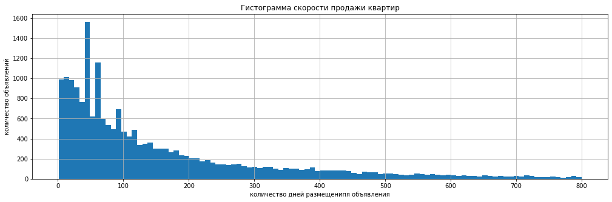

```python
plt.figure(figsize=(17,5))
data['days_exposition'].hist(bins=100, range=(1, 800))
plt.title('Гистограмма скорости продажи квартир')
plt.ylabel('количество объявлений')
plt.xlabel('количество дней размещенипя объявления')
plt.show()
```

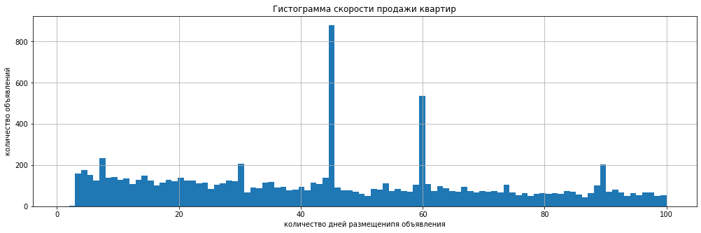

```python
plt.figure(figsize=(17,5))
data['days_exposition'].hist(bins=100, range=(1,100))
plt.title('Гистограмма скорости продажи квартир')
plt.ylabel('количество объявлений')
plt.xlabel('количество дней размещенипя объявления')
plt.show()
```

Разброс значений от 1 до 1580, но значения больше 800 встречаются редко, поэтому построим гистграмму по значениям до 800. Есть два пика на 45 и 60 дней. Эти значения сильно выбиваются, сложно представить что так много квартир продается на ровно 45 или 60 день, возможно какие-то объявления удаляют по прошествии определенного времени. Предположение подтверждает также то, что есть небольшие пики на 7, 30 и 90 дней.

##### Посмотрим на числовое описание столбца таблицы.

```python
data_stat['days_exposition'].describe()
```

```
count    19746.000000
mean       176.461916
std        214.832593
min          1.000000
25%         44.000000
50%         93.000000
75%        225.000000
max       1580.000000
Name: days_exposition, dtype: float64
```

В среднем продажа квартиры занимает 3 месяца, продажу меньше чем за полтора месяца можно считать необычно быстрыми, а продажу более чем за 8 месяцев - необычно долгой.

#### Определим какие факторы больше всего влияют на общую (полную) стоимость объекта.

##### Зависимость цены от общей площади.

```python
data_stat['last_price'].corr(data_stat['total_area'])
```

```
0.7580557839783785
```

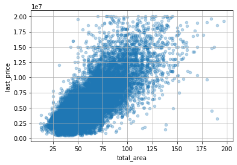

```python
data_stat.plot(y='last_price', x='total_area', kind='scatter', alpha=0.3, grid=True);
```

С увеличением общей площади квартиры увеличивается и общая стоимость квартир. Для квартир площадью менее 100 кв м зависимость более выращена, чем для квартир с большей площадью. В выборке больше всего квартир площадью от 25 до 100 кв м и стоимостью о 1 до 10 млн.

##### Зависимость цены от жилой площади.

```python
data_stat['last_price'].corr(data_stat['living_area'])
```

```
0.6534319105191206
```

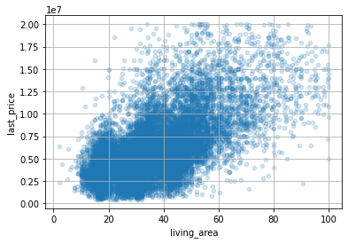

```python
data_stat.plot(y='last_price', x='living_area', kind='scatter', alpha=0.2, grid=True);
```

С увеличением жилой площади квартиры увеличивается и общая стоимость квартир. Наиболее распространенными являются квартиры (три темных пятна): с жилой площадью 15-20 метров и стоимостью от 1 до 7 млн, с площадью от 25 до 35 м и стоимостью от 1.5 до 10 млн, площадью от 40 до 50 м и стоимостью от 2,5 до 10 млн.

##### Зависимость цены от площади кухни.

```python
data_stat['last_price'].corr(data_stat['kitchen_area'])
```

```
0.5748481260903051
```

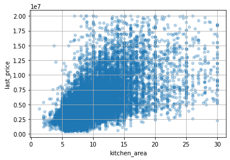

```python
data_stat.plot(y='last_price', x='kitchen_area', kind='scatter', alpha=0.3, grid=True);
```

С увеличением площади кухни квартиры увеличивается и общая стоимость квартир. При площади кухни от 5 до 10 м нижняя граница стоимости практически не меняется, зато верхняя растет от 6 до 10 млн, при площади кухни от 10 до 15 м нижняя граница стоимости растет заметнее, чем верхняя (для верхней границы значения начинают рассеиваться).

##### Зависимость цены от количества комнат.

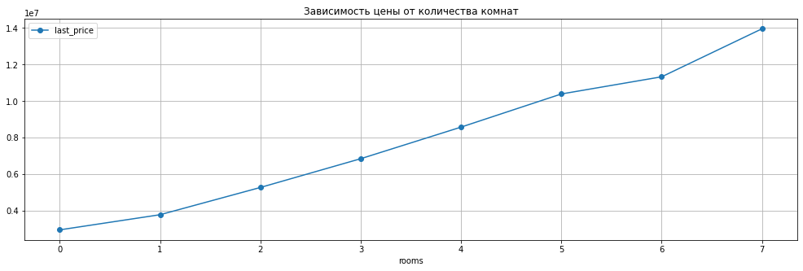

```python
data_stat.pivot_table(
    index='rooms',
    values='last_price').plot(
    style='o-',
    grid=True,
    title = 'Зависимость цены от количества комнат',
    figsize=(17,5));
```

Стоимость квартиры зависит от количества комнат. Одншуки в среднем стоят около 4 млн, двушки - 5,5 млн, трешки - 7 млн и т.д.

##### Зависимость цены от типа этажа.

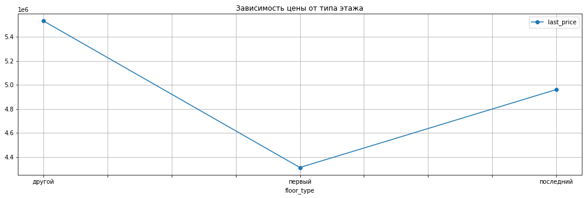

```python
data_stat.pivot_table(
    index='floor_type',
    values='last_price').plot(
    style='o-',
    grid=True,
    title = 'Зависимость цены от типа этажа',
    figsize=(17,5));
```

Стоимость на квартиры не расположенные на первом и последнем этаже выше. Самые дешевые квартиры на перввом этаже.

##### Зависимость цены от даты размещения (день недели).

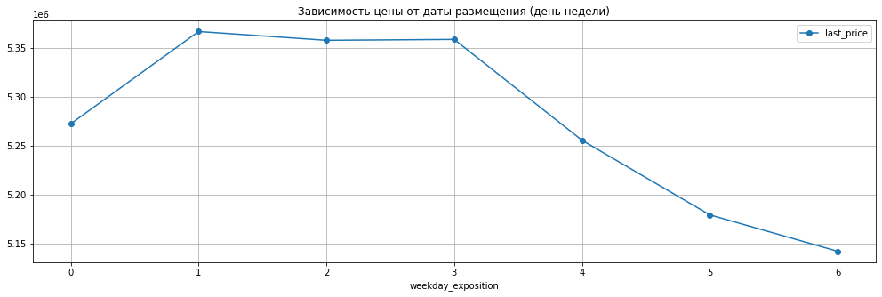

```python
data_stat.pivot_table(index='weekday_exposition', values='last_price').plot(
    style='o-',
    grid=True,
    title = 'Зависимость цены от даты размещения (день недели)',
    figsize=(17,5));
```

##### Зависимость цены от даты размещения (месяц).

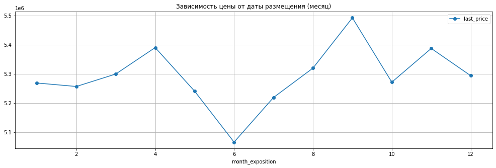

```python
data_stat.pivot_table(
    index='month_exposition',
    values='last_price').plot(
    style='o-',
    grid=True,
    title = 'Зависимость цены от даты размещения (месяц)',
    figsize=(17,5));
```

Самые дорогие квартиры выставляют на продажу в сентябре. С мая по июль наблюдается спад, так же как в декабре и январе.

Перепады вероятно связаны с сезонами праздников и отпусков.

##### Зависимость цены от даты размещения (год).

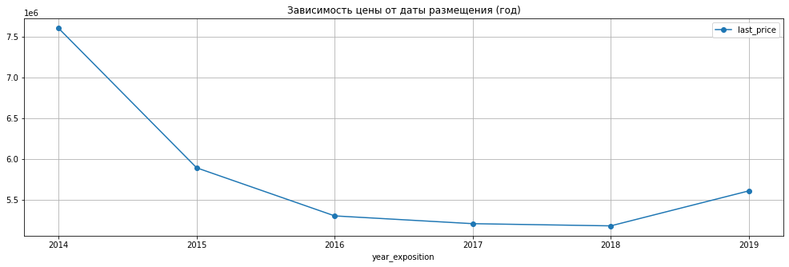

```python
data_stat.pivot_table(
    index='year_exposition',
    values='last_price').plot(
    style='o-',
    grid=True,
    title = 'Зависимость цены от даты размещения (год)',
    figsize=(17,5));
```

В 2014 году размещено больше всего дорогих объявлений, к 2019 цены снова начали расти.

#### Рассчитаем среднюю цену одного квадратного метра в 10 населённых пунктах с наибольшим числом объявлений.

##### Построим сводную таблицу с количеством объявлений и средней ценой квадратного метра для этих населенных пунктов.

```python
data_stat_locality_name = data_stat.pivot_table(index='locality_name', values='meter_price', aggfunc=['count', 'median'])
data_stat_locality_name.columns = ['count', 'mean']
data_stat_locality_name = data_stat_locality_name.sort_values(by='count', ascending=False).head(10)
data_stat_locality_name.sort_values(by='mean', ascending=False)
```

| locality_name | count | mean |
| --- | --- | --- |
| Санкт-Петербург | 14725 | 103448.275862 |
| Пушкин | 354 | 99596.341873 |
| деревня Кудрово | 298 | 91930.232558 |
| поселок Парголово | 326 | 91780.224134 |
| поселок Мурино | 555 | 85714.285714 |
| поселок Шушары | 438 | 76986.128625 |
| Колпино | 337 | 74722.222222 |
| Гатчина | 305 | 67796.610169 |
| Всеволожск | 396 | 65789.473684 |
| Выборг | 235 | 58108.108108 |

Из 10 населённых пунктов с наибольшим числом объявлений самая высокая стоимость квадратного метра в Санкт-Петербурге 103 448 р, самая низкая стоимость квадратного метра во Выборге - 58108 р.

#### Вычислим среднюю стоимость квартир в Санкт-Петербурге на разном удалении от центра.

##### Построим сводную таблицу.

```python
spb = data_stat.query('locality_name == "Санкт-Петербург"')\
    .pivot_table(index='city_centers_nearest_km', values='last_price', aggfunc='median')\
    .sort_values(by='city_centers_nearest_km').astype('int')
spb
```

| city_centers_nearest_km | last_price |
| --- | --- |
| 0.0 | 8795000 |
| 1.0 | 9300000 |
| 2.0 | 8990000 |
| 3.0 | 8000000 |
| 4.0 | 8400000 |
| 5.0 | 8300000 |
| 6.0 | 7700000 |
| 7.0 | 6650000 |
| 8.0 | 6800000 |
| 9.0 | 5200000 |
| 10.0 | 4970000 |
| 11.0 | 4999000 |
| 12.0 | 4950000 |
| 13.0 | 5200000 |
| 14.0 | 4848500 |
| 15.0 | 4875000 |
| 16.0 | 4750000 |
| 17.0 | 4558637 |
| 18.0 | 4295000 |
| 19.0 | 4500000 |
| 20.0 | 4700000 |
| 21.0 | 5220000 |
| 22.0 | 4900000 |
| 23.0 | 4400000 |
| 24.0 | 3480000 |
| 25.0 | 3794881 |
| 26.0 | 3320000 |
| 27.0 | 8300000 |
| 28.0 | 4990000 |
| 29.0 | 4535000 |

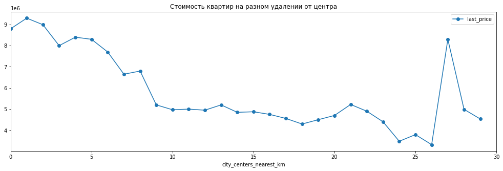

```python
spb.plot( style='o-', xlim=(0, 30), title = 'Стоимость квартир на разном удалении от центра', figsize=(17,5));
```

При удаленни от центра стоимость квартир снижается, за исключением выброса на значении 27 км. Возможно там расположен район, с новостройками премиум класса.

### Вывод

Было рассмотрено числовое описание таблицы. Обработаны аномалии в столбце с высотой потолка. На основании данных числового описания таблицы построим наглядные гистограммы.

Для общей площади пик расположен на значении 45 м, максимальное значение 900, минимальное 12, медианное значение 52, среднее 60. Аномально высокие значения увеличивают среднее арифметическое. Значения от 200 и выше можно отбросить.

Для жилой площади пики расположены на значениях 18 и 30 м, максимальное значение 410, минимальное 2, медианное значение 30, среднее 34. Аномально высокие значения увеличивают среднее арифметическое. Значения от 100 и выше можно отбросить.

Для цены пик расположен на значении 4 000 000, максимальное значение 763 000 000, минимальное 12 190, медианное значение цены 4 600 000, среднее 6 600 000. Аномально высокие значения увеличивают среднее арифметическое. Значения от 20 млн и выше можно отбросить.

Для количства комнат пик расположен на значении 1-2 комнаты , максимальное значение 19, минимальное 0, медианное значение 2, среднее 2. Аномально высокие значения не увеличивают среднее арифметическое, так как их крайне мало. Значения от 8 и выше можно отбросить.

Большинство предложений расположено на этажах типа "другой" (не первый и не последний), распределение первого и последнего этажа равномерное, примерно по 15% от общего числа.

Для количества этажей пики расположены на значениях 5, 9, 12, 17 и 24, максимальное значение 60, минимальное 1, медианное значение 9, среднее 11. Аномально высокие значения незначительно увеличивают среднее арифметическое, потому что их крайне мало. Значения от 30 и выше можно отбросить.

Растояние до центра города чаще всего в районе 10-15 км, разброс от 0 до 66 км.

Для тех квартир, где в радиусе 3 км есть парки, в среднем до ближайщего парка около 500 м.

По числовому описанию и графикам были выявлены и устранены аномалии, отброшены аномально высокие значения и сделан срез данных.

факторами сильнее всего влияющими на стоимость квартир оказались их общая площадь, жилая площадь, площадь кухни, количество комнат и этаж, на которм находится квартира.

С увеличением общей площади квартиры увеличивается и общая стоимость квартир. Для квартир площадью менее 100 кв м зависимость более выращена, чем для квартир с большей площадью. В выборке больше всего квартир площадью от 25 до 100 кв м и стоимостью о 1 до 10 млн.

С увеличением жилой площади квартиры увеличивается и общая стоимость квартир. Наиболее распространенными являются квартиры (три темных пятна): с жилой площадью 15-20 метров и стоимостью от 1 до 7 млн, с площадью от 25 до 35 м и стоимостью от 1.5 до 10 млн, площадью от 40 до 50 м и стоимостью от 2,5 до 10 млн.

С увеличением площади кухни квартиры увеличивается и общая стоимость квартир. При площади кухни от 5 до 10 м нижняя граница стоимости практически не меняется, зато верхняя растет от 6 до 10 млн, при площади кухни от 10 до 15 м нижняя граница стоимости растет заметнее, чем верхняя (для верхней границы значения начинают рассеиваться).

Стоимость квартиры зависит от количества комнат. Одншуки в среднем стоят около 4 млн, двушки - 5,5 млн, трешки - 7 млн и т.д.

Стоимость на квартиры не расположенные на первом и последнем этаже выше. Самые дешевые квартиры на перввом этаже.

Самые дорогие квартиры выставляют на продажу в сентябре. С мая по июль наблюдается спад, так же как в декабре и январе.

В 2014 году размещено больше всего дорогих объявлений, к 2019 цены снова начали расти.

Далее была рассчитана средняя цена одного квадратного метра в 10 населённых пунктах с наибольшим числом объявлений.

Из 10 населённых пунктов с наибольшим числом объявлений самая высокая стоимость квадратного метра в Санкт-Петербурге 103 т.р, самая низкая стоимость квадратного метра во Выборге - 58 т.р.

Средняя стоимость квартир в Санкт-Петербурге при удаленни от центра снижается, за исключением выброса на значении 27 км. Возможно там расположен район, с новостройками премиум класса.

### Напишите общий вывод

Пропуски присутствуют в 14 столбцах. Отношение пропусков к общему количеству данных доходит до 90% от данных столбца.

По построенным гистограммам видно, что во многих числовых данных (количество фотографий, цена, общая площадь, высота потолков, количество комнат, количество этажей дома, этаж, жилая площадь, площадь кухни) есть выбросы аномально высоких значений. Для того, чтобы более наглядно рассмотреть струтуру распределение данных, в разделе 4 необходимо вывести таблицу с подробным описанием числовых данных и построить новые гистограммы, в каждой из которых будет индивидуально подобрано оптимальное количество корзин и исключены аномально высокие значения.

Тип данных стобца is_apartment изменен с object на bool. Во-первых это было необходимо для проверки предположения о том, что пропуски в площади кухни и жилой площади связаны с типом квартиры. Во-вторых начения типа bool занимают намного меньше памяти, чем значения типа object.

Для значений столбцов с ценой, количеством балконов, количеством парков и водоемов в радиусе 3 км, можно использовать целочисленные значения, причем для последних трех можно использовать тип int8, так как там нужны числа только от 0 до 5, это сократит объем занимаемой памяти примерно на 14%.

Пропуски в высоте потолков и общему количеству этажей можно заполнить медианными значениями этих столбцов, а пропуски в столбцах с жилой площадью и площадью кухни заполнить с помощью данных об общей площади квартиры.

Если в объявлении не указано количество балконов - вероятно их нет, поэтому пропущенные значения заменены на 0.

Если не указано количество парков и водоемов в радиусе 3 км - вероятно их нет, поэтому пропущенные значения заменены на 0.

Пропускам в столбце названия населенного пункта присвоено значение "Другое".

Пропуски в данных о жилой площади, площади кухни и высоте потолков можно объяснить человеческим фактором (автор объявления решил не указывать эти данные), техническим сбоем.

Было найдено и удалено 36 неявных дубликатов в столбце с названиями населенных пунктов, из 365 осталось 329.

Явных дубликатов в данных не обнаружено.

Для дальнейшего проведения анализа были добавлены столбцы: цена одного квадратного метра; день недели публикации объявления (0 — понедельник, 1 — вторник и так далее); месяц публикации объявления; год публикации объявления; тип этажа квартиры (значения — «первый», «последний», «другой»); расстояние до центра города в километрах.

Было рассмотрено числовое описание таблицы. Обработаны аномалии в столбце с высотой потолка. На основании данных числового описания таблицы построим наглядные гистограммы.

Для общей площади пик расположен на значении 45 м, максимальное значение 900, минимальное 12, медианное значение 52, среднее 60. Аномально высокие значения увеличивают среднее арифметическое. Значения от 200 и выше можно отбросить.

Для жилой площади пики расположены на значениях 18 и 30 м, максимальное значение 410, минимальное 2, медианное значение 30, среднее 34. Аномально высокие значения увеличивают среднее арифметическое. Значения от 100 и выше можно отбросить.

Для цены пик расположен на значении 4 000 000, максимальное значение 763 000 000, минимальное 12 190, медианное значение цены 4 600 000, среднее 6 600 000. Аномально высокие значения увеличивают среднее арифметическое. Значения от 20 млн и выше можно отбросить.

Для количства комнат пик расположен на значении 1-2 комнаты , максимальное значение 19, минимальное 0, медианное значение 2, среднее 2. Аномально высокие значения не увеличивают среднее арифметическое, так как их крайне мало. Значения от 8 и выше можно отбросить.

Большинство предложений расположено на этажах типа "другой" (не первый и не последний), распределение первого и последнего этажа равномерное, примерно по 15% от общего числа.

Для количества этажей пики расположены на значениях 5, 9, 12, 17 и 24, максимальное значение 60, минимальное 1, медианное значение 9, среднее 11. Аномально высокие значения незначительно увеличивают среднее арифметическое, потому что их крайне мало. Значения от 30 и выше можно отбросить.

Растояние до центра города чаще всего в районе 10-15 км, разброс от 0 до 66 км.

Для тех квартир, где в радиусе 3 км есть парки, в среднем до ближайщего парка около 500 м.

По числовому описанию и графикам были выявлены и устранены аномалии, отброшены аномально высокие значения и сделан срез данных.

факторами сильнее всего влияющими на стоимость квартир оказались их общая площадь, жилая площадь, площадь кухни, количество комнат и этаж, на которм находится квартира.

С увеличением общей площади квартиры увеличивается и общая стоимость квартир. Для квартир площадью менее 100 кв м зависимость более выращена, чем для квартир с большей площадью. В выборке больше всего квартир площадью от 25 до 100 кв м и стоимостью о 1 до 10 млн.

С увеличением жилой площади квартиры увеличивается и общая стоимость квартир. Наиболее распространенными являются квартиры (три темных пятна): с жилой площадью 15-20 метров и стоимостью от 1 до 7 млн, с площадью от 25 до 35 м и стоимостью от 1.5 до 10 млн, площадью от 40 до 50 м и стоимостью от 2,5 до 10 млн.

С увеличением площади кухни квартиры увеличивается и общая стоимость квартир. При площади кухни от 5 до 10 м нижняя граница стоимости практически не меняется, зато верхняя растет от 6 до 10 млн, при площади кухни от 10 до 15 м нижняя граница стоимости растет заметнее, чем верхняя (для верхней границы значения начинают рассеиваться).

Стоимость квартиры зависит от количества комнат. Одншуки в среднем стоят около 4 млн, двушки - 5,5 млн, трешки - 7 млн и т.д.

Стоимость на квартиры не расположенные на первом и последнем этаже выше. Самые дешевые квартиры на перввом этаже.

Самые дорогие квартиры выставляют на продажу в сентябре. С мая по июль наблюдается спад, так же как в декабре и январе.

В 2014 году размещено больше всего дорогих объявлений, к 2019 цены снова начали расти.

Далее была рассчитана средняя цена одного квадратного метра в 10 населённых пунктах с наибольшим числом объявлений.

Из 10 населённых пунктов с наибольшим числом объявлений самая высокая стоимость квадратного метра в Санкт-Петербурге 103 т.р, самая низкая стоимость квадратного метра во Выборге - 58 т.р.

Средняя стоимость квартир в Санкт-Петербурге при удаленни от центра снижается, за исключением выброса на значении 27 км. Возможно там расположен район, с новостройками премиум класса.